# WB-XAI-2 - praca domowa 3

Mateusz Grzyb

[figure not shown]

## Wczytanie i obróbka danych oraz przygotowanie modelu

Wczytane dane obrabiam w ten sam sposób, jak na poprzedniej pracy domowej. Model również tworzę w analogiczny sposób.

```r
# wczytanie bibliotek
library(OpenML)

# wczytanie danych
blood <- getOMLDataSet(data.id = 1464)
blood <- blood$data

# obrobka wstępna
row.names(blood) <- NULL
names(blood) <- c('Recency', 'Frequency', 'Monetary', 'Time', 'Donated')
blood$Donated <- factor(ifelse(blood$Donated==2, 1, 0))
blood <- blood[-3]

# dodanie zaproponowanej ostatnio zmiennej Intensity
blood_m <- cbind(
  blood[c('Recency', 'Frequency')],
  Intensity=pmin(blood$Frequency/pmax(blood$Time-blood$Recency, 1), 1),
  blood['Donated'])

# podglad ramki danych
head(blood_m)
```

|  | Recency | Frequency | Intensity | Donated |
| --- | --- | --- | --- | --- |
| 1 | 2 | 50 | 0.5208333 | 1 |
| 2 | 0 | 13 | 0.4642857 | 1 |
| 3 | 1 | 16 | 0.4705882 | 1 |
| 4 | 2 | 20 | 0.4651163 | 1 |
| 5 | 1 | 24 | 0.3157895 | 0 |
| 6 | 4 | 4 | 1.0000000 | 0 |

```r
# wczytanie bibliotek
library(mlr)
library(PRROC)

# przygotowanie modelu
corr <- round(cor(blood_m[-4], method='spearman'), 2)
c2 <- apply(corr, 1, FUN=function(x) {sum(x^2)})
c2 <- c2/sum(c2)

classif_task <- makeClassifTask(id='blood_m', data=blood_m, target='Donated')
classif_lrn <- makeLearner('classif.ranger', predict.type='prob')

model <- train(classif_lrn, classif_task)

# diagnostyka modelu
pred <- predict(model, classif_task)$data$prob.1

fg <- pred[blood$Donated==1]
bg <- pred[blood$Donated==0]

roc <- roc.curve(scores.class0=fg, scores.class1=bg, curve=T)
pr <- pr.curve(scores.class0=fg, scores.class1=bg, curve=T)
```

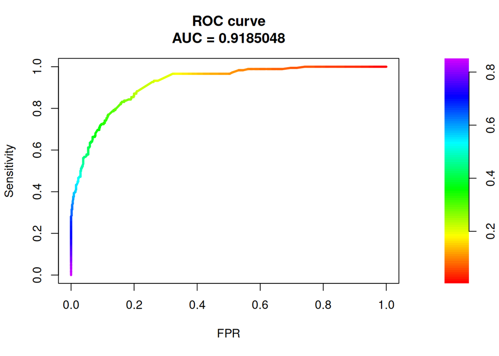

```r
# wykres roc
plot(roc)
```

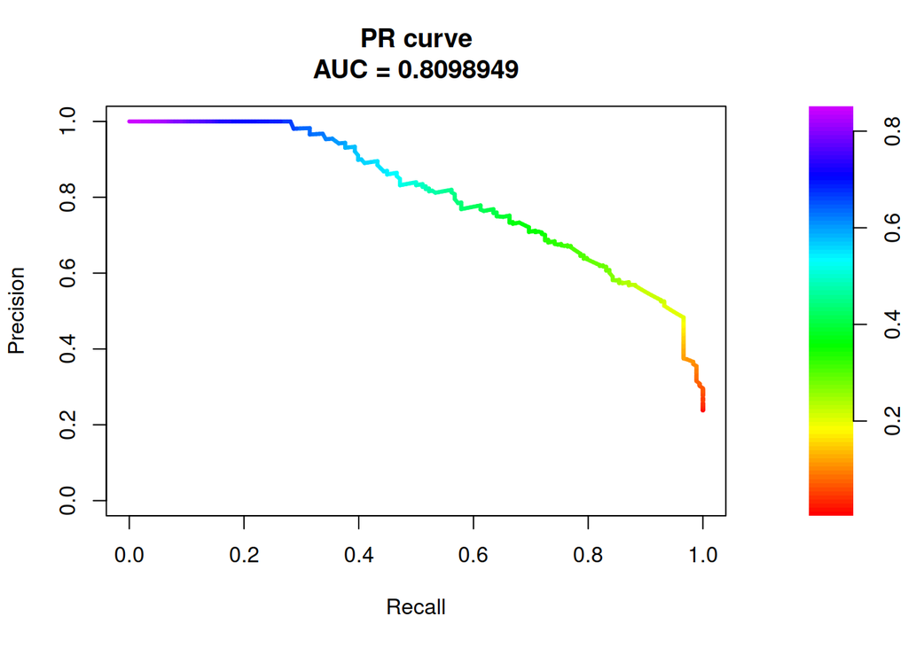

```r
# wykres pr
plot(pr)
```

Model jest całkiem trafny.

## Właściwa część pracy domowej

Stwórzmy najpierw instancję explainera.

```r
library(DALEX)
library(DALEXtra)

explainer <- explain(model=model, data=blood_m, y=as.numeric(blood$Donated), label='mlr.ranger', colorize=FALSE)
```

```
## Preparation of a new explainer is initiated
##   -> model label       :  mlr.ranger
##   -> data              :  748  rows  4  cols
##   -> target variable   :  748  values
##   -> predict function  :  yhat.WrappedModel  will be used (  default  )
##   -> predicted values  :  No value for predict function target column. (  default  )
##   -> model_info        :  package mlr , ver. 2.19.0 , task classification (  default  )
##   -> predicted values  :  numerical, min =  0.008060182 , mean =  0.239497 , max =  0.8473539
##   -> residual function :  difference between y and yhat (  default  )
##   -> residuals         :  numerical, min =  0.3359225 , mean =  0.9984709 , max =  1.931397
##   A new explainer has been created!
```

Poniżej znajdują się rozwiązania poszczególnych podpunktów pracy domowej.

“Dla wybranej obserwacji ze zbioru danych wylicz predykcję modelu.”

```r
obs <- blood_m[342, ]
obs
```

|  | Recency | Frequency | Intensity | Donated |
| --- | --- | --- | --- | --- |
| 342 | 23 | 38 | 0.5066667 | 0 |

Pod obserwacją 342 kryje się osoba, którego swego czasu często (średnio raz na dwa miesiące) i wielokrotnie (dokładnie 38 razy) oddawała krew, ale nie robiła tego od niemal dwóch lat.

```r
pred <- predict(model, newdata=obs)
pred$data
```

|  | truth | prob.0 | prob.1 | response |
| --- | --- | --- | --- | --- |
| 342 | 0 | 0.8284985 | 0.1715015 | 0 |

Model poprawnie i z dużą pewnością przewiduje, że osoba ta nie wróciła oddać krwi w marcu 2007.

“Dla wybranej obserwacji z punktu 1., wylicz dekompozycję predykcji modelu używając profili Ceteris Paribus”

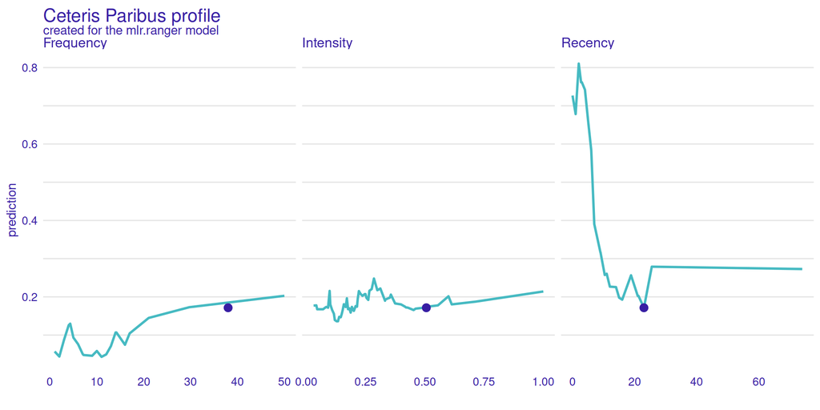

```r
model_predict <- predict_profile(explainer, new_observation=blood_m[342, 1:3], variable_splits_type='quantiles')
plot(model_predict)
```

Wyjaśnienie Ceteris Paribus dla tej obserwacji pokazuje nam, że wyłącznie zmniejszenie zmiennej Recency ma w przypadku tej obserwacji znaczący wpływ. Jest to całkiem logiczne - nie ważne, jak swego czasu aktywna była dana osoba, ponieważ fakt, że nie oddawała krwi od niemal dwóch lat nie rokuje dobrze.

“Wybierz dwie obserwacje ze zbioru danych, które mają różne profile CP (na przykład: dla obserwacji A odpowiedź modelu rośnie wraz ze wzrostem wartości zmiennej, a dla obserwacji B maleje).”

```r
obs <- blood_m[c(43, 16), ]
obs
```

|  | Recency | Frequency | Intensity | Donated |
| --- | --- | --- | --- | --- |
| 43 | 2 | 5 | 0.3571429 | 1 |
| 16 | 2 | 5 | 0.5555556 | 1 |

Wybrałem dwie obserwacje, które posiadają takie samo niskie Recency i przeciętne Frequency, ale inne Intensity.

```r
blood[c(43, 16), ]
```

|  | Recency | Frequency | Time | Donated |
| --- | --- | --- | --- | --- |
| 43 | 2 | 5 | 16 | 1 |
| 16 | 2 | 5 | 11 | 1 |

```r
pred <- predict(model, newdata=obs)
pred$data
```

|  | truth | prob.0 | prob.1 | response |
| --- | --- | --- | --- | --- |
| 43 | 1 | 0.4496444 | 0.5503556 | 1 |
| 16 | 1 | 0.2418100 | 0.7581900 | 1 |

Model poprawnie przewiduje, że obie osoby oddadzą krew ponownie w marcu 2007.

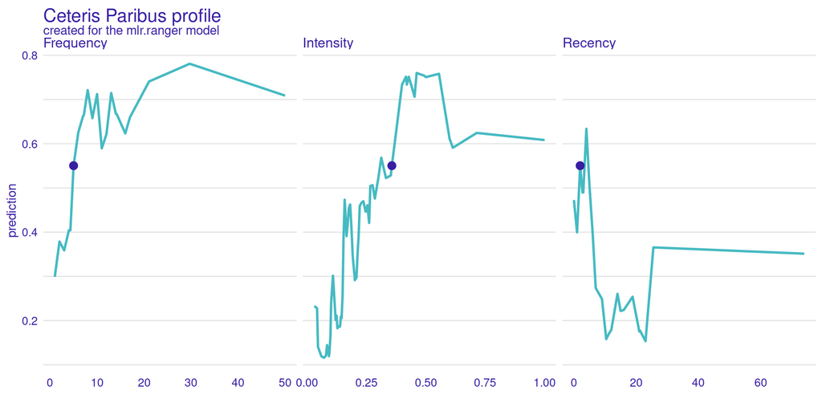

```r
model_predict <- predict_profile(explainer, new_observation=blood_m[43, 1:3], variable_splits_type='quantiles')
plot(model_predict)
```

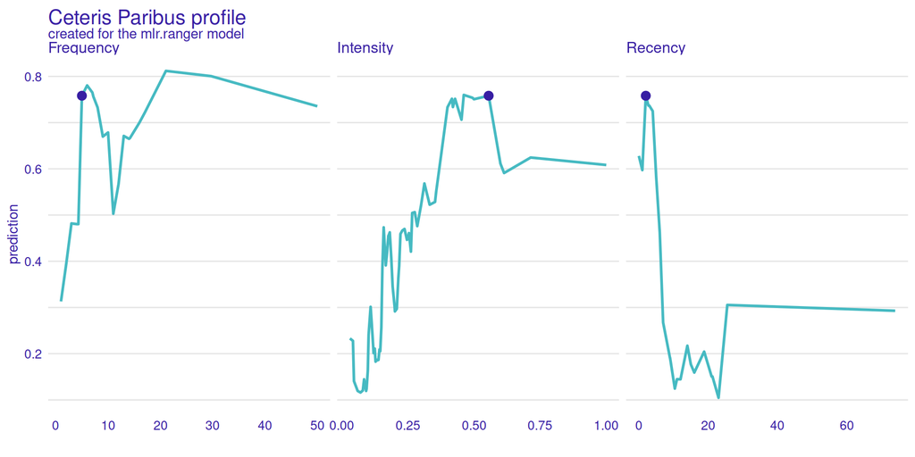

```r
model_predict <- predict_profile(explainer, new_observation=blood_m[16, 1:3], variable_splits_type='quantiles')
plot(model_predict)
```

Obie obserwacje posiadają niemal idealną (z punktu widzenia predykcji) wartość Recency.

Dla obserwacji 43 nieznaczne zwiększenie Intensity miałoby pozytywny (0.55 -> 0.75) wpływ na predykcję.

Dla obserwacji 16 sytuacja jest odwrotna - nieznaczne zwiększenie Intensity miałoby negatywny (0.75 -> 0.6) wpływ na predykcję.

Zgaduję, że może tutaj chodzić o coś w stylu wypalenia - osoby, które w krótkim czasie wielokrotnie oddawały krew mają większą szansę na porzucenie tej czynności, w porównaniu do osób, które robiły to w nieco spokojniejszym tempie.

```r
a <- blood_m[blood_m$Recency==2 & blood$Time < 48 & blood_m$Intensity < 0.55 , 4] == 1
b <- blood_m[blood_m$Recency==2 & blood$Time < 48 & blood_m$Intensity > 0.55 & blood$Time < 24, 4] == 1
```

```r
cat(paste0(round(sum(a)/length(a), 2)*100, '% out of ', length(a), ' people with Time < 48 and Intensity < 0.55 did donate.\n'))
```

```
## 43% out of 90 people with Time < 48 and Intensity < 0.55 did donate.
```

```r
cat(paste0(round(sum(b)/length(b), 2)*100, '% out of ', length(b), ' people with Time < 48 and Intensity > 0.55 did donate.\n'))
```

```
## 28% out of 47 people with Time < 48 and Intensity > 0.55 did donate.
```

Powyżej znajduje się próba potwierdzenia mojej teorii. Rzeczywiście coś może być na rzeczy.

Najlepiej jednak będzie użyć testu statystycznego.

```r
# https://en.wikipedia.org/wiki/Fisher%27s_exact_test
fisher.test(rbind(c(sum(a), length(a) - sum(a)), c(sum(b), length(b) - sum(b))), alternative = 'greater')
```

```
##
##  Fisher's Exact Test for Count Data
##
## data:  rbind(c(sum(a), length(a) - sum(a)), c(sum(b), length(b) - sum(b)))
## p-value = 0.05265
## alternative hypothesis: true odds ratio is greater than 1
## 95 percent confidence interval:
##  0.9906884       Inf
## sample estimates:
## odds ratio
##   1.990095
```

p-value na poziomie 0.05265 sugeruje, że może to nie być tylko przypadek.

```r
prop.test(c(sum(a), sum(b)), c(length(a), length(b)), alternative = 'greater')
```

```
##
##  2-sample test for equality of proportions with continuity correction
##
## data:  c(sum(a), sum(b)) out of c(length(a), length(b))
## X-squared = 2.5898, df = 1, p-value = 0.05378
## alternative hypothesis: greater
## 95 percent confidence interval:
##  0.003066631 1.000000000
## sample estimates:
##    prop 1    prop 2
## 0.4333333 0.2765957
```

Inny test, ale podobny wynik.

Warto zwrócić uwagę, że jest to obserwacja, której nie możemy poczynić posługując się metodami SHAP czy LIME.

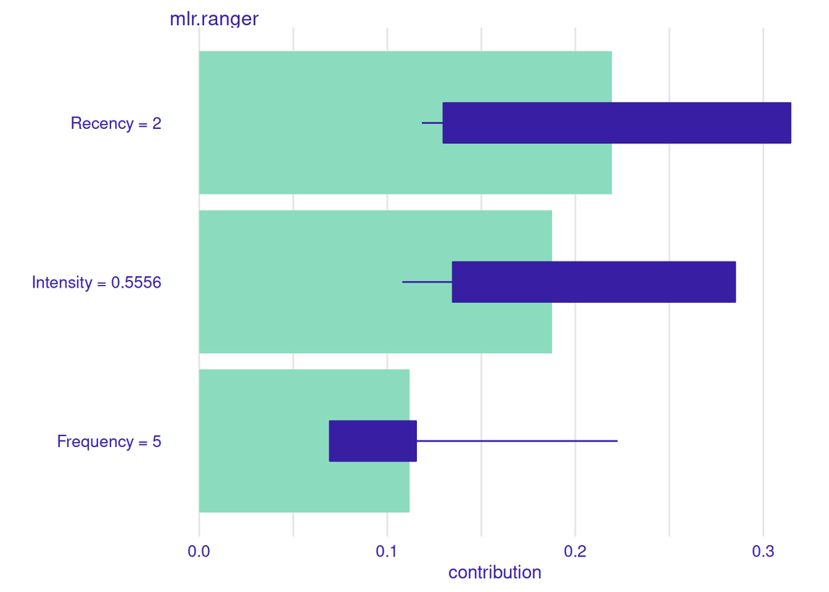

```r
sh <- predict_parts(explainer, new_observation=blood_m[16, 1:3], type='shap')
plot(sh)
```

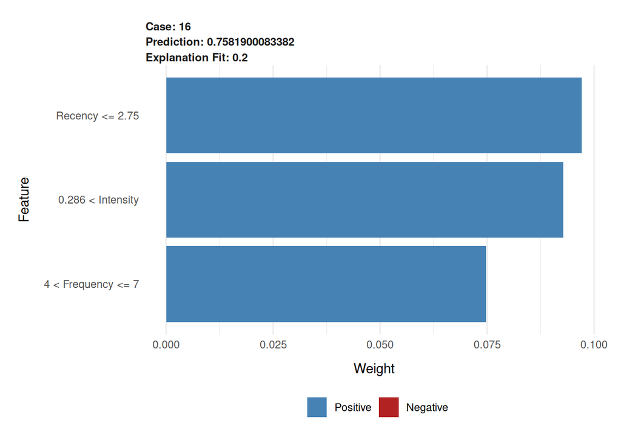

```r
model_type.dalex_explainer <- DALEXtra::model_type.dalex_explainer
predict_model.dalex_explainer <- DALEXtra::predict_model.dalex_explainer

lime <- predict_surrogate(
  explainer=explainer,
  new_observation=blood_m[16, ],
  n_features=3,
  n_permutations=1000,
  type='lime'
  )

plot(lime)
```